# Lab 01 - Hello R

Kryschelle Fakir

1/16/2026

## Load packages and data

```r
library(tidyverse)
library(datasauRus)
data("datasaurus_dozen")
```

## Exercises

### Exercise 1

There are 1846 rows and 3 columns in the datasaurus_dozen file. The variables are dataset (tells which dataset the data are from), x (for x-values), and y (for the y-values).

### Exercise 2

First, the data in the dino dataset is plotted. The first line is telling r to filter the datasauraus_dozen dataframe for instances where the dataset = dino. The second line is aiming to visualize the data where the x and y columns get mapped as points using the aes function. Then the geom function is telling r which shapes we want to represent the data:

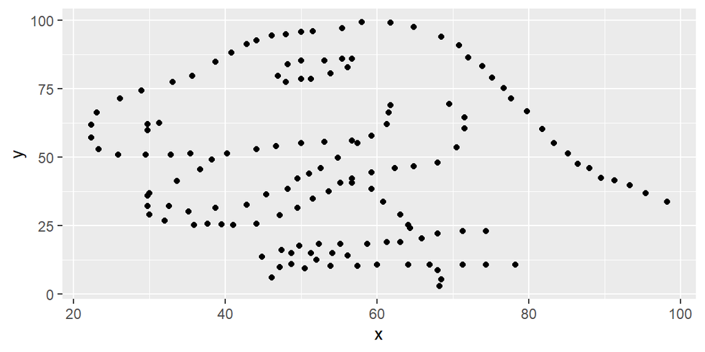

```r
dino_data <- datasaurus_dozen %>%
  filter(dataset == "dino")

ggplot(data = dino_data, mapping = aes(x = x, y = y)) +
  geom_point()
```

Next, the correlation between `x` and `y` in this dataset is calculated. The cor function refers to the correlation coefficient, r (hehehe), and we’re telling R to calculate the correlation of the variables x and y of the dataset we filtered out from the dataframe above:

```r
dino_data %>%
  summarize(r = cor(x, y))
```

```
## # A tibble: 1 × 1
##         r
##     <dbl>
## 1 -0.0645
```

### Exercise 3

To begin, we will filter out the ‘star’ data from the datasaurus_dozen dataframe so we can have the specific x and y values needed to graph the star. We will call him Patrick. Then we will tell R to graph the x and y values of the filtered dataset. We will then specify that R graph these data using geometric points.

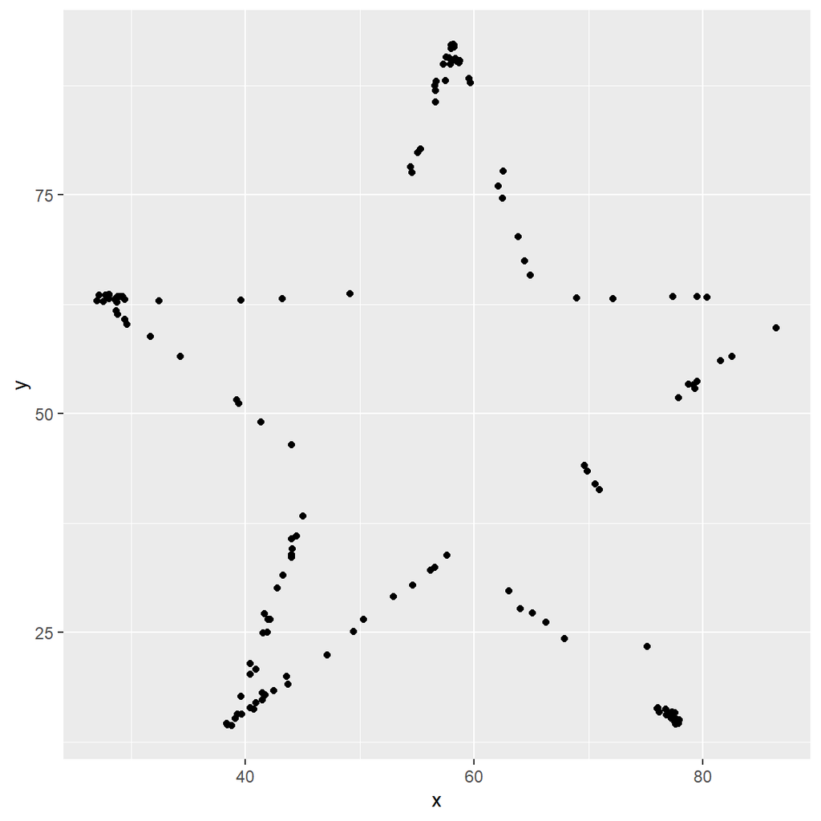

```r
star_data <- datasaurus_dozen %>%
  filter(dataset == "star")

ggplot(data = star_data, mapping = aes(x = x, y = y)) +
  geom_point()
```

To calculate the correlation coefficient of the star, we will tell R to run the correlation on variables x and y in the star_data dataset using the cor function.

```r
star_data %>%
  summarize(r = cor(x, y))
```

```
## # A tibble: 1 × 1
##         r
##     <dbl>
## 1 -0.0630
```

The star and dino correlations are incredibly similar. The star correlation is -0.063 and the dino correlation is -0.064. Both relationships are curvilinear, so a value of -0.06 may be accounting for the lack of a linear relationship – hence why they’re both so similar.

### Exercise 4

To begin, we will filter out cases in the datasaurus_dozen dataframe that come from the circle dataset. Then we will plot the x and y values from the x and y variables from the filtered dataset.

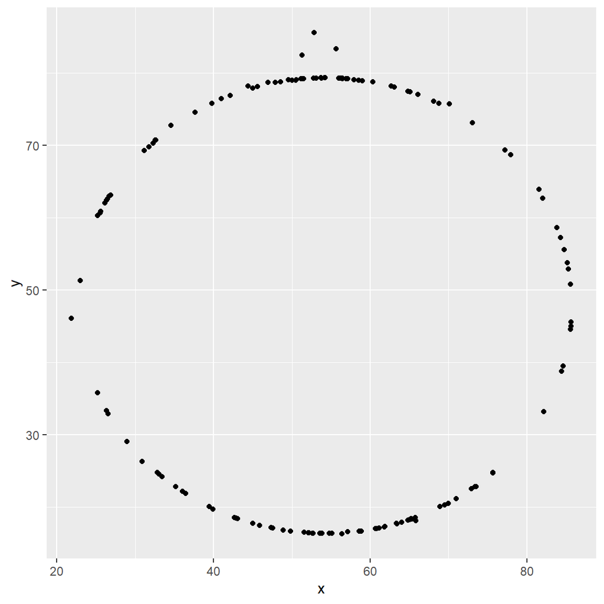

```r
circle_data <- datasaurus_dozen %>%
  filter(dataset == "circle")

ggplot(data = circle_data, mapping = aes(x = x, y = y)) +
  geom_point()
```

Next, we will tell R to caluclate the correlation coefficient of x and y from the circle dataset.

```r
circle_data %>%
  summarize(r = cor(x, y))
```

```
## # A tibble: 1 × 1
##         r
##     <dbl>
## 1 -0.0683
```

The correlation for the circle relationship is stronger than th dino relationship and the star relationship. However, the r value is still centered around -0.06, suggesting that this value does arise from the presence of a curvilinear relationship.

We will now plot all of the datasets included in the datasaurus_dozen dataframe. Now they can all shine…

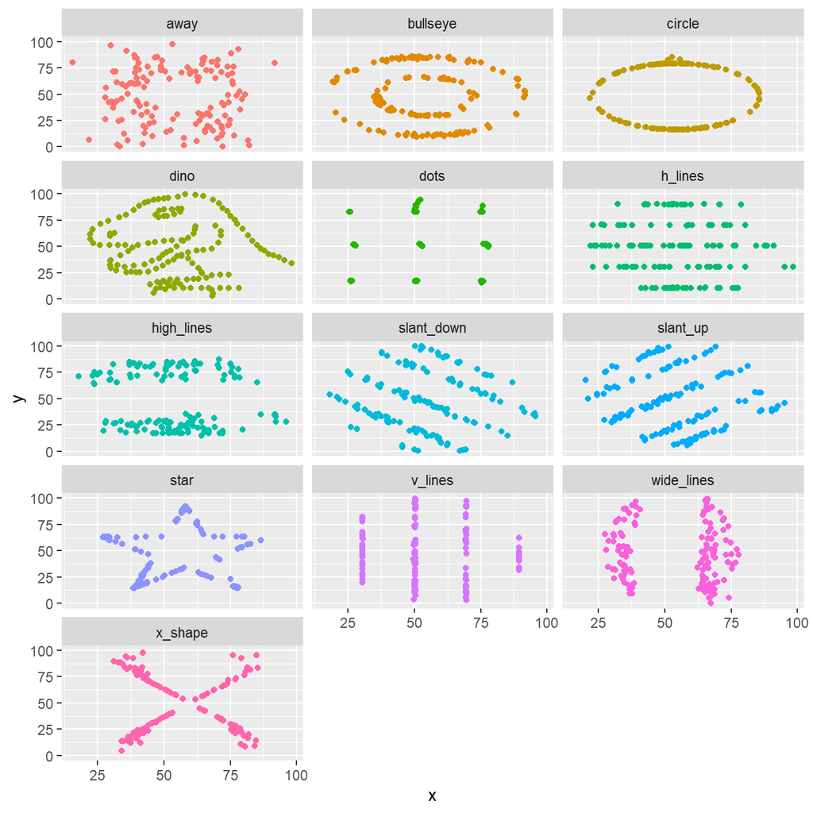

```r
ggplot(datasaurus_dozen, aes(x = x, y = y, color = dataset)) +
  geom_point() +
  facet_wrap(~dataset, ncol = 3) +
  theme(legend.position = "none")
```

```r
datasaurus_dozen %>%
  group_by(dataset) %>%
  summarize(r = cor(x, y)) %>%
  print(13)
```

```
## # A tibble:
## #   13 × 2
##    dataset
##    <chr>
##  1 away
##  2 bullseye
##  3 circle
##  4 dino
##  5 dots
##  6 h_lines
##  7 high_lines
##  8 slant_down
##  9 slant_up
## 10 star
## 11 v_lines
## 12 wide_lines
## 13 x_shape
## # ℹ 1 more
## #   variable:
## #   r <dbl>
```

### Bullseye

I am also curious what bullseye looks like…

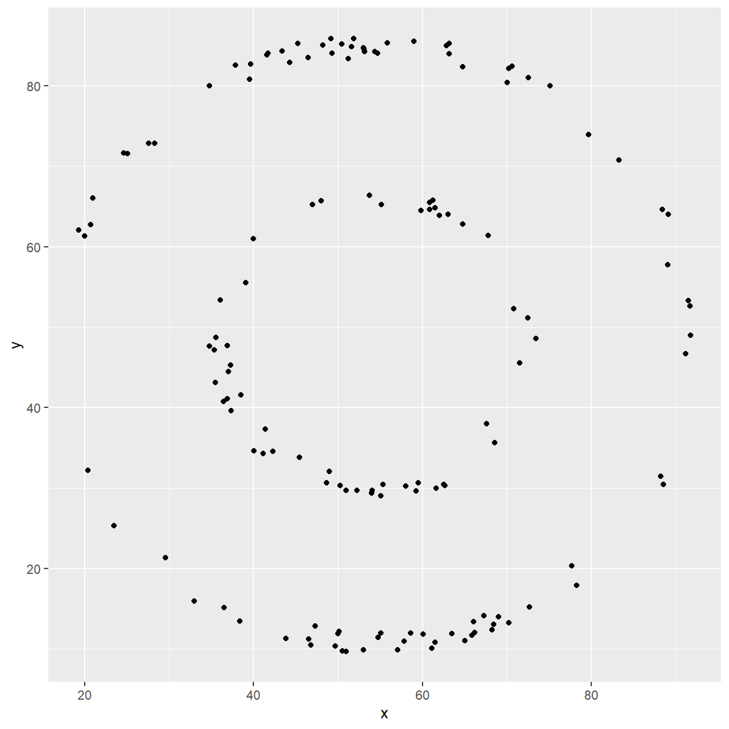

```r
bullseye_data <- datasaurus_dozen %>%
  filter(dataset == "bullseye")

ggplot(data = bullseye_data, mapping = aes(x = x, y = y)) +
  geom_point()
```

WOAH!!!

### Away

What is away??

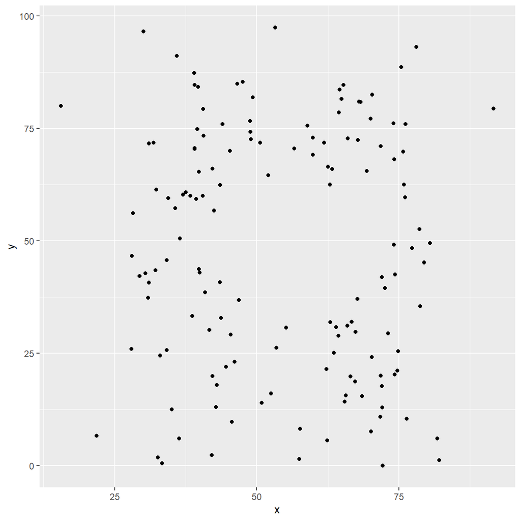

```r
away_data <- datasaurus_dozen %>%
  filter(dataset == "away")

ggplot(data = away_data, mapping = aes(x = x, y = y)) +
  geom_point()
```

gnarly…